# Dnyanai_Surkutwar_Take_Home_test

### K =11 We see that error is min at 11 and 29 (a little more lower than 11), So lets take k=11 first,then:

```python
knn11 = KNeighborsClassifier(n_neighbors=11)
```

```python
knn11.fit(X_train,y_train)
```

```
KNeighborsClassifier(algorithm='auto', leaf_size=30, metric='minkowski',
                     metric_params=None, n_jobs=None, n_neighbors=11, p=2,
                     weights='uniform')
```

```python
y_pred11 = knn11.predict(X_test)
```

```python
accuracy_score(y_test,y_pred11)
```

```
0.8439897698209718
```

```python
conf = confusion_matrix(y_test, y_pred11)
```

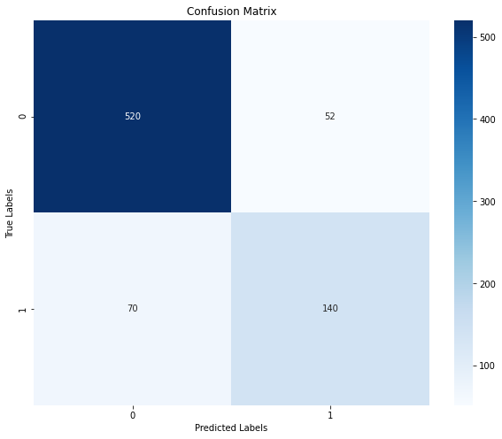

```python
confmatrix(conf, 11)
```

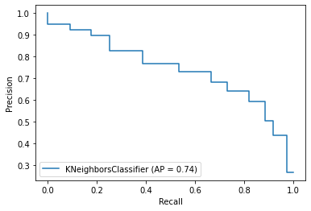

```python
plt.figure(figsize=(10,8))
plot_precision_recall_curve(knn11,X_test,y_test)
plt.show()
```

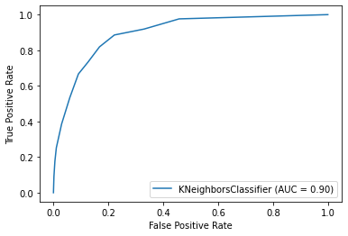

```python
plt.figure(figsize=(10,8))
plot_roc_curve(knn11,X_test,y_test)
plt.show()
```

```python
print(classification_report(y_test, y_pred11))
```

```
              precision    recall  f1-score   support

           0       0.88      0.91      0.90       572
           1       0.73      0.67      0.70       210

    accuracy                           0.84       782
   macro avg       0.81      0.79      0.80       782
weighted avg       0.84      0.84      0.84       782
```

```python
error_rate_11 = []
error_rate_11.append(np.mean(y_pred11 != y_test))
print('The error involved in KNN model with k=11 is around:',round((error_rate_11[0])*100,3),'%')
```

```
The error involved in KNN model with k=11 is around: 15.601 %
```

### K = 29

```python
knn29 = KNeighborsClassifier(n_neighbors=29)
```

```python
knn29.fit(X_train,y_train)
```

```
KNeighborsClassifier(algorithm='auto', leaf_size=30, metric='minkowski',
                     metric_params=None, n_jobs=None, n_neighbors=29, p=2,
                     weights='uniform')
```

```python
y_pred29 = knn.predict(X_test)
```

```python
accuracy_score(y_test,y_pred29)
```

```
0.8452685421994884
```

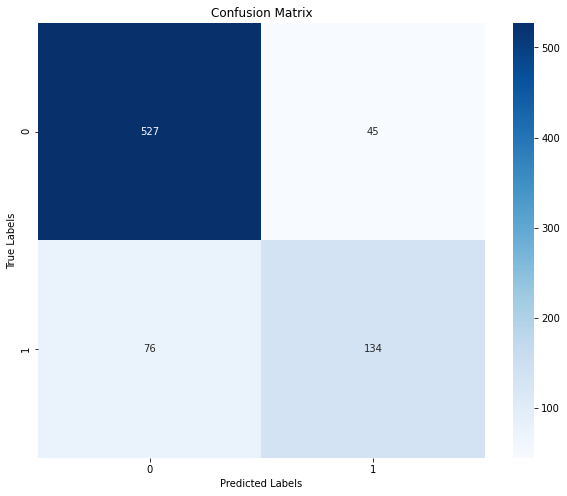

```python
conf = confusion_matrix(y_test, y_pred29)
confmatrix(conf, 29)
```

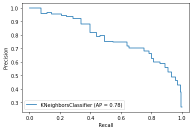

```python
plt.figure(figsize=(10,8))
plot_precision_recall_curve(knn29,X_test,y_test)
plt.show()
```

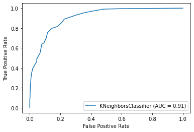

```python
plt.figure(figsize=(10,8))
plot_roc_curve(knn29,X_test,y_test)
plt.show()
```

```python
print(classification_report(y_test, y_pred29))
```

```
              precision    recall  f1-score   support

           0       0.87      0.92      0.90       572
           1       0.75      0.64      0.69       210

    accuracy                           0.85       782
   macro avg       0.81      0.78      0.79       782
weighted avg       0.84      0.85      0.84       782
```

```python
error_rate_29 = []
error_rate_29.append(np.mean(y_pred29 != y_test))
print('The error involved in KNN model with k=29 is around:',round((error_rate_29[0])*100,3),'%')
```

```
The error involved in KNN model with k=29 is around: 15.473 %
```

### Therefore, For K =1, 11, 29, we have the best accuracy for K=29. Ther recall and precision for class 1 will be still less than class 0 as we our data is highly biased towards class 0.

### Performing K-fold cross validation to see if our accuracy imporves further more:

```python
# Lets check for odd numbers first to make it time efficient to find the K for KNN
neighbors = list(range(1, 30,2))

# Making an empty list to store the cross validation scores
cv_scores = []

# perform 10-fold cross validation
for k in neighbors:
    knn_cv = KNeighborsClassifier(n_neighbors=k)
    scores = cross_val_score(knn_cv, X_train,y_train, cv=5, scoring='accuracy')
    cv_scores.append(scores.mean())
```

```python
cv_scores
```

```
[0.7987099938123245,
 0.8226936225123309,
 0.8289073611565447,
 0.8355166771595837,
 0.8350811512725693,
 0.8371788209991895,
 0.8389597375066089,
 0.8393160320155226,
 0.8399096917353536,
 0.84066158709762,
 0.8412554426051797,
 0.8418491414825564,
 0.8410971834682167,
 0.8414928313106241,
 0.840068130997027]
```

```
The optimal number of neighbors is 23
```

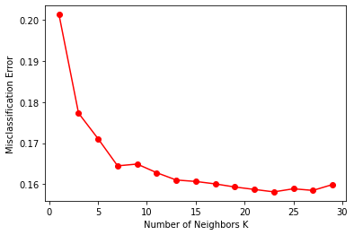

```python
# changing to misclassification error
mse = [1 - x for x in cv_scores]

# determining best k
optimal_k = neighbors[mse.index(min(mse))]
print("The optimal number of neighbors is {}".format(optimal_k))

# plot misclassification error vs k
plt.plot(neighbors, mse, 'r-',marker='o')
plt.xlabel("Number of Neighbors K")
plt.ylabel("Misclassification Error")
plt.show()
```

```python
#Setup a knn classifier with k neighbors
knn_cv = KNeighborsClassifier(n_neighbors=optimal_k)
```

```python
#Fit the model
knn_cv.fit(X_train,y_train)
```

```
KNeighborsClassifier(algorithm='auto', leaf_size=30, metric='minkowski',
                     metric_params=None, n_jobs=None, n_neighbors=23, p=2,
                     weights='uniform')
```

```python
#let us get the predictions using the classifier we had fit above
y_pred_cv = knn_cv.predict(X_test)
```

```python
# Get accuracy for the K-fold cross validated model
print('The model accuracy with K-Fold Cross Validation is:',round(knn_cv.score(X_test,y_test)*100,3),'%')
```

```
The model accuracy with K-Fold Cross Validation is: 83.887 %
```

```python
error_rate_cv = [] ## create an empty list
error_rate_cv.append(np.mean(y_pred_cv != y_test)) ##take the mean/avg of the y_pred values which are not ini_Y_test
print('The error involved in K-fold cross validation tuned model is around:',round((error_rate_cv[0])*100,3),'%')
```

```
The error involved in K-fold cross validation tuned model is around: 16.113 %
```

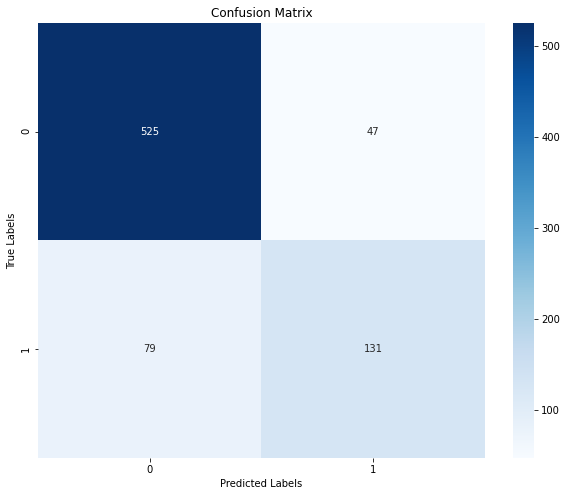

```python
conf = confusion_matrix(y_test, y_pred_cv)
confmatrix(conf, 23)
```

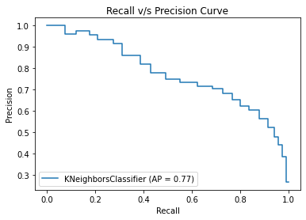

```python
plt.figure(figsize=(10,8))
plot_precision_recall_curve(knn_cv,X_test,y_test)
plt.title('Recall v/s Precision Curve')
plt.show()
```

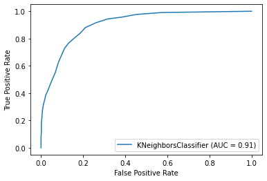

```python
plt.figure(figsize=(10,8))
plot_roc_curve(knn_cv,X_test,y_test)
plt.show()
```

```python
print(classification_report(y_test, y_pred_cv))
```

```
              precision    recall  f1-score   support

           0       0.87      0.92      0.89       572
           1       0.74      0.62      0.68       210

    accuracy                           0.84       782
   macro avg       0.80      0.77      0.78       782
weighted avg       0.83      0.84      0.83       782
```

```python
error_rate_cv = []
error_rate_cv.append(np.mean(y_pred_cv != y_test))
print('The error involved in K-Fold CV tuned model is around:',round((error_rate_cv[0])*100,3),'%')
```

```
The error involved in K-Fold CV tuned model is around: 16.113 %
```

### Using GridSearch CV:

```python
##n_neighbors is the parameter for tuning knn and we are also giving metric
param_grid = {'n_neighbors':np.arange(1,30,2)}
```

```python
knn_gs = KNeighborsClassifier() ## Knn classfier for hrid search (explicit)

knn_gs_o = GridSearchCV(knn_gs,param_grid,verbose=1,cv=5,n_jobs=-1,return_train_score=True) ## here we are specifying cv as 5 fold
knn_gs_o.fit(X_train,y_train) ## fitting the model on our training data
```

```
Fitting 5 folds for each of 15 candidates, totalling 75 fits
```

```
[Parallel(n_jobs=-1)]: Using backend LokyBackend with 2 concurrent workers.
[Parallel(n_jobs=-1)]: Done  46 tasks      | elapsed: 26.4min
[Parallel(n_jobs=-1)]: Done  75 out of  75 | elapsed: 48.4min finished
```

```
GridSearchCV(cv=5, error_score=nan,
             estimator=KNeighborsClassifier(algorithm='auto', leaf_size=30,
                                            metric='minkowski',
                                            metric_params=None, n_jobs=None,
                                            n_neighbors=5, p=2,
                                            weights='uniform'),
             iid='deprecated', n_jobs=-1,
             param_grid={'n_neighbors': array([ 1,  3,  5,  7,  9, 11, 13, 15, 17, 19, 21, 23, 25, 27, 29])},
             pre_dispatch='2*n_jobs', refit=True, return_train_score=True,
             scoring=None, verbose=1)
```

```python
knn_gs_o.best_params_
## This is giving us the k value for which the model has got the best results
```

```
{'n_neighbors': 23}
```

```python
print('The best score for model for k=23 is:',round(knn_gs_o.best_score_*100,2),'%')
```

```
The best score for model for k=23 is: 84.18 %
```

```python
#let us get the predictions using the classifier we had fit above
y_pred_gs_o = knn_gs_o.predict(X_test)
```

```python
error_rate_gs = []
error_rate_gs.append(np.mean(y_pred_gs_o != y_test))
print('The error involved in gridsearchCV tuned model is around:',round((error_rate_gs[0])*100,3),'%')
```

```
The error involved in gridsearchCV tuned model is around: 16.113 %
```

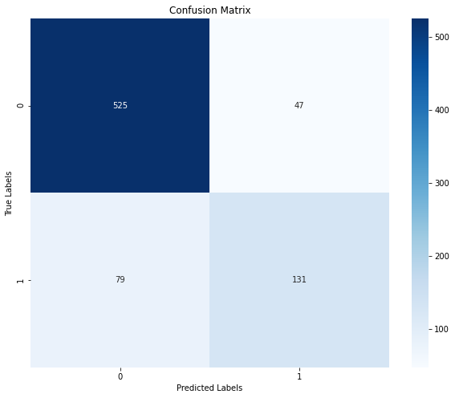

```python
conf = confusion_matrix(y_test, y_pred_gs_o)
confmatrix(conf, 23)
```

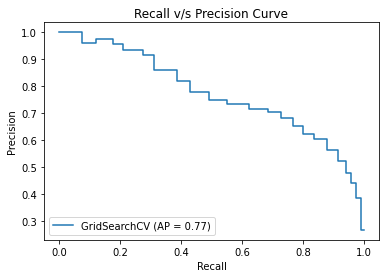

```python
plt.figure(figsize=(10,8))
plot_precision_recall_curve(knn_gs_o,X_test,y_test)
plt.title('Recall v/s Precision Curve')
plt.show()
```

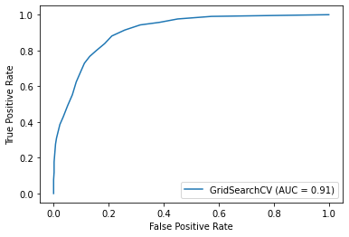

```python
plt.figure(figsize=(10,8))
plot_roc_curve(knn_gs_o,X_test,y_test)
plt.show()
```

```python
print(classification_report(y_test, y_pred_gs_o))
```

```
              precision    recall  f1-score   support

           0       0.87      0.92      0.89       572
           1       0.74      0.62      0.68       210

    accuracy                           0.84       782
   macro avg       0.80      0.77      0.78       782
weighted avg       0.83      0.84      0.83       782
```

```python
print('The accuracy and error rate using just the accuarcy method with k=1 is:',\
      round(knn1.score(X_test,y_test)*100,3),'% and ',round((error_rate_1[0])*100,3),'%')
print('\nThe accuracy and error rate using just the accuarcy method with k=11 is:',\
      round(knn11.score(X_test,y_test)*100,3),'% and ',round((error_rate_11[0])*100,3),'%')
print('\nThe accuracy and error rate using just the accuarcy method with k=29 is:',\
      round(knn29.score(X_test,y_test)*100,3),'% and ',round((error_rate_29[0])*100,3),'%')
print('Best Accuracy')
print('\nThe accuracy and error rate using k-Fold cross validation method with k=',optimal_k,'is:',\
      round(knn_cv.score(X_test,y_test)*100,3),'% and ',round((error_rate_cv[0])*100,3),'%')
print('Best generalized model')
print('\nThe accuracy and error rate using Grid Search cross validation method with k=23 is:',\
      round(knn_gs_o.best_score_*100,3),'% and ',round((error_rate_gs[0])*100,3),'%')
print('Best generalized model')
```

[output not shown]

# 8. Improving the dataset issues: We noticed that the dataset is highly imbalanced, this may be solved by either oversampling or SMOTE to try to balance the number of samples for both the class labels. The number of categories in the categorical columns need to preprocessed before giving input to the model, this is evident from the native country column as if we do not process it then the model has almost 95 columns which adds a lot of computational time and is unecc for this dataset. The dataset is highly biased, even if we try to sample the data and level the dataset I feel for this dataset, it would be systhetically editting the dataset which would not help us. But, just by data preprocessing we got ~85% accuracy so I think if we use Random Forrest classifier we might be able to boost the model accuracy a bit. The Cross Validated model gives the most realistic model accuracy though we notice that for a vanilla knn model at k=29 we have higher accuracy. This shows that even if we have less accuracy having a more model which generalizes well is more imp. The predicted_y on test dataset is done for Knn where K=29. back

# 9. Prepping the test dataset: back

```python
df_test.shape
```

```
(6512, 16)
```

```python
df_test.head()
```

|  | rowid | age | workclass | fnlwgt | education | education_num | marital_status | occupation | relationship | race | sex | capital_gain | capital_loss | hours_per_week | native_country | yearly_income |
| --- | --- | --- | --- | --- | --- | --- | --- | --- | --- | --- | --- | --- | --- | --- | --- | --- |
| 0 | 2 | 52 | Private | 198863 | Prof-school | 15 | Divorced | Exec-managerial | Not-in-family | White | Male | 0 | 2559 | 60 | United-States | ? |
| 1 | 7 | 49 | Private | 175622 | Masters | 14 | Married-civ-spouse | Prof-specialty | Husband | White | Male | 0 | 0 | 40 | United-States | ? |
| 2 | 8 | 32 | Private | 279173 | Bachelors | 13 | Divorced | Sales | Not-in-family | White | Male | 0 | 0 | 45 | United-States | ? |
| 3 | 10 | 51 | Private | 306790 | HS-grad | 9 | Divorced | Craft-repair | Not-in-family | White | Male | 0 | 0 | 40 | United-States | ? |
| 4 | 13 | 29 | Private | 169544 | Assoc-voc | 11 | Never-married | Tech-support | Not-in-family | White | Male | 0 | 0 | 40 | United-States | ? |

```python
df_xtest = df_test.drop('yearly_income', axis=1)
```

### Replicating feature selection and feature / data wrangling set for df_test:

```python
for each in list(df_xtest.columns):
    if len(df_xtest[each][df_xtest[each]== '?']) != 0:
        print('\n',each, '-', df_xtest[each].dtype, '\n Num of ?\'s:', len(df_xtest[each][df_xtest[each]== '?']), \
              '\n Total # of rows:', len(df_xtest), \
              '\n Percentage of ?\'s present (%):',round(len(df_xtest[each][df_xtest[each]== '?'])/len(df_xtest)*100,2))
```

```
 workclass - object
 Num of ?'s: 371
 Total # of rows: 6512
 Percentage of ?'s present (%): 5.7

 occupation - object
 Num of ?'s: 372
 Total # of rows: 6512
 Percentage of ?'s present (%): 5.71

 native_country - object
 Num of ?'s: 97
 Total # of rows: 6512
 Percentage of ?'s present (%): 1.49
```

```python
## First lets replace all the '?' with NaN so that we can use fillna function:
df_xtest.replace('?', np.nan, inplace=True)
```

```python
df_xtest.isna().sum()
```

```
rowid               0
age                 0
workclass         371
fnlwgt              0
education           0
education_num       0
marital_status      0
occupation        372
relationship        0
race                0
sex                 0
capital_gain        0
capital_loss        0
hours_per_week      0
native_country     97
dtype: int64
```

```python
for each in list(df_xtest.columns):
    if df_xtest[each].isna().sum() > 0:
        print(each,df_xtest[each].mode()[0])
        df_xtest[each].fillna(df_xtest[each].mode()[0], inplace=True)
```

```
workclass Private
occupation Craft-repair
native_country United-States
```

## Data Wrangling/Cleaning (Part 2) and Feature Engineering for model:

### We understood how each column is in the data, for modelling we can merge some similar looking categories together to decrease the feature space. Also, we need to create a new feature called as Change_in_capital.

```python
df_xtest.head()
```

|  | rowid | age | workclass | fnlwgt | education | education_num | marital_status | occupation | relationship | race | sex | capital_gain | capital_loss | hours_per_week | native_country |
| --- | --- | --- | --- | --- | --- | --- | --- | --- | --- | --- | --- | --- | --- | --- | --- |
| 0 | 2 | 52 | Private | 198863 | Prof-school | 15 | Divorced | Exec-managerial | Not-in-family | White | Male | 0 | 2559 | 60 | United-States |
| 1 | 7 | 49 | Private | 175622 | Masters | 14 | Married-civ-spouse | Prof-specialty | Husband | White | Male | 0 | 0 | 40 | United-States |
| 2 | 8 | 32 | Private | 279173 | Bachelors | 13 | Divorced | Sales | Not-in-family | White | Male | 0 | 0 | 45 | United-States |
| 3 | 10 | 51 | Private | 306790 | HS-grad | 9 | Divorced | Craft-repair | Not-in-family | White | Male | 0 | 0 | 40 | United-States |
| 4 | 13 | 29 | Private | 169544 | Assoc-voc | 11 | Never-married | Tech-support | Not-in-family | White | Male | 0 | 0 | 40 | United-States |

### Decreasing the number of categories on Education column:

```python
df_xtest.education.value_counts()
```

```
HS-grad         2127
Some-college    1445
Bachelors       1060
Masters          364
Assoc-voc        286
11th             232
Assoc-acdm       209
10th             188
7th-8th          122
Prof-school      109
9th               93
12th              89
Doctorate         79
5th-6th           64
1st-4th           34
Preschool         11
Name: education, dtype: int64
```

### Lets club the school grades as school since these just mean that people either just completed primary or secondary school and did not finish high school.

```python
## Making a new column for qualification:
df_xtest['education_level'] = df_xtest.education
```

```python
df_xtest.education_level.loc[df_xtest.education=='Preschool'] = 'School'
df_xtest.education_level.loc[df_xtest.education=='1st-4th'] = 'School'
df_xtest.education_level.loc[df_xtest.education=='5th-6th'] = 'School'
df_xtest.education_level.loc[df_xtest.education=='7th-8th'] = 'School'
df_xtest.education_level.loc[df_xtest.education=='9th'] = 'School'
df_xtest.education_level.loc[df_xtest.education=='10th'] = 'School'
df_xtest.education_level.loc[df_xtest.education=='11th'] = 'School'
df_xtest.education_level.loc[df_xtest.education=='12th'] = 'School'
```

### Associate degrees are mostly offered in community colleges, so lets club associate degrees into Associate degrees too.

```python
df_xtest.education_level.loc[df_xtest.education=='Assoc-voc'] = 'Associates'
df_xtest.education_level.loc[df_xtest.education=='Assoc-acdm'] = 'Associates'
```

### Native_country column:

```python
len(df_xtest.native_country.unique())
```

```
40
```

```python
## Changing the native_country cloumn to binary as almost 91+% data is in the USA:
df_xtest['country'] = df_xtest.native_country.apply(lambda x: 0 if x != 'United-States' else 1)
```

```python
df_xtest.country.value_counts()
```

```
1    5963
0     549
Name: country, dtype: int64
```

### Making new feature 'Change_in_Capital':

```python
df_xtest['change_capital'] = df_xtest['capital_gain'] - df_xtest['capital_loss']
```

### Lets drop all the redundant features not required for the model:

```python
df_xtest.columns
```

```
Index(['rowid', 'age', 'workclass', 'fnlwgt', 'education', 'education_num',
       'marital_status', 'occupation', 'relationship', 'race', 'sex',
       'capital_gain', 'capital_loss', 'hours_per_week', 'native_country',
       'education_level', 'country', 'change_capital'],
      dtype='object')
```

```python
df_xtest.shape
```

```
(6512, 18)
```

```python
df_xtest.drop(columns=['capital_gain','capital_loss', 'education', 'education_num', \
                  'rowid', 'fnlwgt', 'native_country']\
         , axis=1, inplace=True)
```

```python
df_xtest.shape
```

```
(6512, 11)
```

```python
df_xtest.info()
```

```
<class 'pandas.core.frame.DataFrame'>
RangeIndex: 6512 entries, 0 to 6511
Data columns (total 11 columns):
 #   Column           Non-Null Count  Dtype
---  ------           --------------  -----
 0   age              6512 non-null   int64
 1   workclass        6512 non-null   object
 2   marital_status   6512 non-null   object
 3   occupation       6512 non-null   object
 4   relationship     6512 non-null   object
 5   race             6512 non-null   object
 6   sex              6512 non-null   object
 7   hours_per_week   6512 non-null   int64
 8   education_level  6512 non-null   object
 9   country          6512 non-null   int64
 10  change_capital   6512 non-null   int64
dtypes: int64(4), object(7)
memory usage: 559.8+ KB
```

```python
df_xtest.columns
```

```
Index(['age', 'workclass', 'marital_status', 'occupation', 'relationship',
       'race', 'sex', 'hours_per_week', 'education_level', 'country',
       'change_capital'],
      dtype='object')
```

```python
df_tcat = df_xtest.select_dtypes(include='object')
df_tnum = df_xtest.select_dtypes(exclude='object')
print('Dataframe of numerical features:',df_tnum.shape)
print('dataframe of categorical features:',df_tcat.shape)
```

```
Dataframe of numerical features: (6512, 4)
dataframe of categorical features: (6512, 7)
```

### As discussed previously, we will frist Standardize the numerical features in df_num:

```python
## We are manually doing this as we do not want to use the scaler from scikitlearn
##as before splitting our data the scaler will know the data and this shouldnt happen to the test data we split from the training data
for i in df_tnum:
    df_tnum.loc[:,i] = (df_tnum.loc[:,i]-np.mean(df_tnum.loc[:,i]))/(np.std(df_tnum.loc[:,i]))
```

```python
df_tnum.head()
```

|  | age | hours_per_week | country | change_capital |
| --- | --- | --- | --- | --- |
| 0 | 0.978517 | 1.618919 | 0.303427 | -0.48293 |
| 1 | 0.760242 | -0.035660 | 0.303427 | -0.13413 |
| 2 | -0.476650 | 0.377984 | 0.303427 | -0.13413 |
| 3 | 0.905759 | -0.035660 | 0.303427 | -0.13413 |
| 4 | -0.694925 | -0.035660 | 0.303427 | -0.13413 |

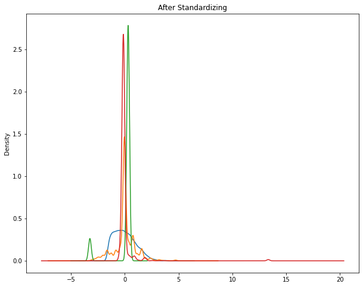

```python
## We already know that this dataset is biased and we cannot change that much but now its in the same scale:
plt.figure(figsize=(10,8))
for each in df_tnum:
  plt.title('After Standardizing')
  df_num[each].plot(kind='kde')
```

### One-hot encoding the categorical dataframe df_cat (we are right now keeping all the categorical features):

```python
df_tcat = pd.get_dummies(df_tcat)
```

```python
df_tcat.shape
```

```
(6512, 50)
```

```python
df_tcat.head()
```

|  | workclass_Federal-gov | workclass_Local-gov | workclass_Never-worked | workclass_Private | workclass_Self-emp-inc | workclass_Self-emp-not-inc | workclass_State-gov | workclass_Without-pay | marital_status_Divorced | marital_status_Married-AF-spouse | marital_status_Married-civ-spouse | marital_status_Married-spouse-absent | marital_status_Never-married | marital_status_Separated | marital_status_Widowed | occupation_Adm-clerical | occupation_Armed-Forces | occupation_Craft-repair | occupation_Exec-managerial | occupation_Farming-fishing | occupation_Handlers-cleaners | occupation_Machine-op-inspct | occupation_Other-service | occupation_Priv-house-serv | occupation_Prof-specialty | occupation_Protective-serv | occupation_Sales | occupation_Tech-support | occupation_Transport-moving | … |
| --- | --- | --- | --- | --- | --- | --- | --- | --- | --- | --- | --- | --- | --- | --- | --- | --- | --- | --- | --- | --- | --- | --- | --- | --- | --- | --- | --- | --- | --- | --- |
| 0 | 0 | 0 | 0 | 1 | 0 | 0 | 0 | 0 | 1 | 0 | 0 | 0 | 0 | 0 | 0 | 0 | 0 | 0 | 1 | 0 | 0 | 0 | 0 | 0 | 0 | 0 | 0 | 0 | 0 | … |
| 1 | 0 | 0 | 0 | 1 | 0 | 0 | 0 | 0 | 0 | 0 | 1 | 0 | 0 | 0 | 0 | 0 | 0 | 0 | 0 | 0 | 0 | 0 | 0 | 0 | 1 | 0 | 0 | 0 | 0 | … |
| 2 | 0 | 0 | 0 | 1 | 0 | 0 | 0 | 0 | 1 | 0 | 0 | 0 | 0 | 0 | 0 | 0 | 0 | 0 | 0 | 0 | 0 | 0 | 0 | 0 | 0 | 0 | 1 | 0 | 0 | … |
| 3 | 0 | 0 | 0 | 1 | 0 | 0 | 0 | 0 | 1 | 0 | 0 | 0 | 0 | 0 | 0 | 0 | 0 | 1 | 0 | 0 | 0 | 0 | 0 | 0 | 0 | 0 | 0 | 0 | 0 | … |
| 4 | 0 | 0 | 0 | 1 | 0 | 0 | 0 | 0 | 0 | 0 | 0 | 0 | 1 | 0 | 0 | 0 | 0 | 0 | 0 | 0 | 0 | 0 | 0 | 0 | 0 | 0 | 0 | 1 | 0 | … |

### Time to bring both df_cat and df_num into one Dataframe:

```python
main_t = pd.concat([df_tnum, df_tcat], axis=1)
```

```python
main_t.shape
```

```
(6512, 54)
```

```python
main_t.head()
```

|  | age | hours_per_week | country | change_capital | workclass_Federal-gov | workclass_Local-gov | workclass_Never-worked | workclass_Private | workclass_Self-emp-inc | workclass_Self-emp-not-inc | workclass_State-gov | workclass_Without-pay | marital_status_Divorced | marital_status_Married-AF-spouse | marital_status_Married-civ-spouse | marital_status_Married-spouse-absent | marital_status_Never-married | marital_status_Separated | marital_status_Widowed | occupation_Adm-clerical | occupation_Armed-Forces | occupation_Craft-repair | occupation_Exec-managerial | occupation_Farming-fishing | occupation_Handlers-cleaners | occupation_Machine-op-inspct | occupation_Other-service | occupation_Priv-house-serv | occupation_Prof-specialty | … |
| --- | --- | --- | --- | --- | --- | --- | --- | --- | --- | --- | --- | --- | --- | --- | --- | --- | --- | --- | --- | --- | --- | --- | --- | --- | --- | --- | --- | --- | --- | --- |
| 0 | 0.978517 | 1.618919 | 0.303427 | -0.48293 | 0 | 0 | 0 | 1 | 0 | 0 | 0 | 0 | 1 | 0 | 0 | 0 | 0 | 0 | 0 | 0 | 0 | 0 | 1 | 0 | 0 | 0 | 0 | 0 | 0 | … |
| 1 | 0.760242 | -0.035660 | 0.303427 | -0.13413 | 0 | 0 | 0 | 1 | 0 | 0 | 0 | 0 | 0 | 0 | 1 | 0 | 0 | 0 | 0 | 0 | 0 | 0 | 0 | 0 | 0 | 0 | 0 | 0 | 1 | … |
| 2 | -0.476650 | 0.377984 | 0.303427 | -0.13413 | 0 | 0 | 0 | 1 | 0 | 0 | 0 | 0 | 1 | 0 | 0 | 0 | 0 | 0 | 0 | 0 | 0 | 0 | 0 | 0 | 0 | 0 | 0 | 0 | 0 | … |
| 3 | 0.905759 | -0.035660 | 0.303427 | -0.13413 | 0 | 0 | 0 | 1 | 0 | 0 | 0 | 0 | 1 | 0 | 0 | 0 | 0 | 0 | 0 | 0 | 0 | 1 | 0 | 0 | 0 | 0 | 0 | 0 | 0 | … |
| 4 | -0.694925 | -0.035660 | 0.303427 | -0.13413 | 0 | 0 | 0 | 1 | 0 | 0 | 0 | 0 | 0 | 0 | 0 | 0 | 1 | 0 | 0 | 0 | 0 | 0 | 0 | 0 | 0 | 0 | 0 | 0 | 0 | … |

```python
X_test_test = main_t
y_pred_pred = np.NaN
```

```python
X_test_test.shape
```

```
(6512, 54)
```

```python
y_pred_pred = knn29.predict(X_test_test)
```

```python
predicted_y = pd.DataFrame(y_pred_pred)
```

```python
predicted_y.head()
```

|  | 0 |
| --- | --- |
| 0 | 1 |
| 1 | 1 |
| 2 | 0 |
| 3 | 0 |
| 4 | 0 |

```python
predicted_y.value_counts()
```

```
0    5255
1    1257
dtype: int64
```

```python
predicted_y[0].to_csv('/content/drive/MyDrive/Colab Notebooks/Noodle.ai/IncomePredictionTest.txt', index = False)
```

```python
!apt-get install texlive texlive-xetex texlive-latex-extra pandoc
!pip install pypandoc
```

```python
!jupyter nbconvert --to PDF "Dnyanai_Surkutwar_Home_test.ipynb"
```

[output not shown]

[output cut: 75 more lines]

[output not shown]